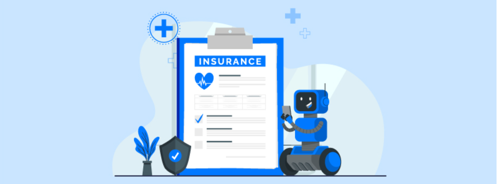

# *BENEFITS OF USING MACHINE LEARNING IN INSUR-TECH INDUSTRY -*

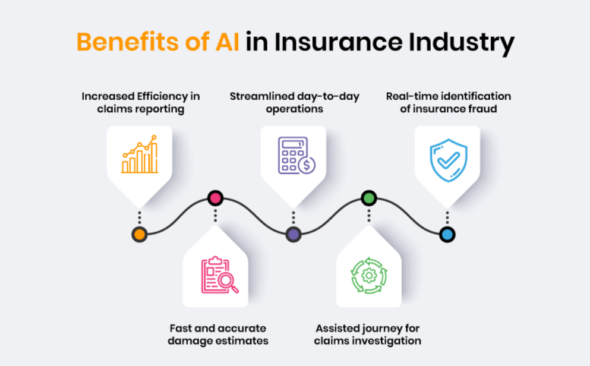

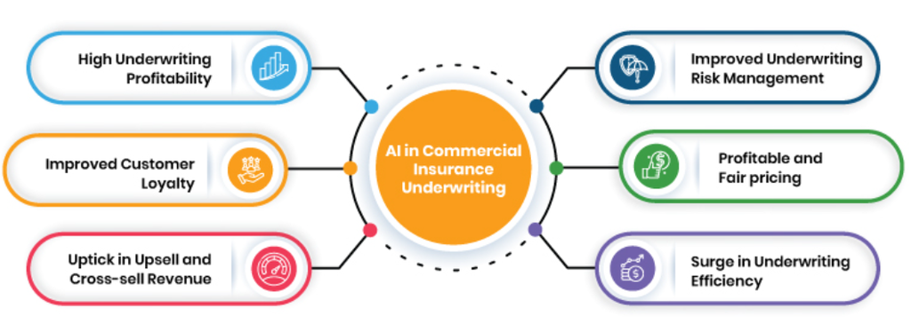

# *Future Insurance Claim Price Prediction Model and its Main Key Factors-*

An American corporate insurance company has been researching on their project and is planning to provide both current and potential clientele a new insurance program. According to their current client's financial lifestyle and physical condition, the top executive is curious as to whether a certain customer will purchase this new insurance plan or, at the very least, renew the existing plan. If yes, explain the key factors that will determine the cost of this new insurance plan as well as what each client may fairly expect to spend when renewing their current insurance plan in the future. So, being a Business Insights Analyst, we have two goals to accomplish here – 1)Identify the Key factors that will influence the purchase of this new Insurance plan. 2)Identify the future amount that each client fairly expect to spend when renewing their current insurance plan.

# *List of Python Libraries used for this particular project -*

```python
from warnings import filterwarnings
filterwarnings("ignore")
import pandas as pd
from os import chdir
import seaborn as sb
import matplotlib.pyplot as mlp
from numpy import unique
from sklearn.preprocessing import StandardScaler
from sklearn.model_selection import train_test_split
from statsmodels.api import OLS
from sklearn.linear_model import LinearRegression
from sklearn.tree import DecisionTreeRegressor
from sklearn.ensemble import RandomForestRegressor
from sklearn.neighbors import KNeighborsRegressor
from sklearn.metrics import r2_score
from sklearn.metrics import mean_squared_error
from sklearn.metrics import mean_absolute_error
```

# *1)Read the Data-*

```python
import pandas as pd

from os import chdir
chdir("F:/Raw Datasets/Finance/Life Insurance")

data = pd.read_csv("insurance.csv")
```

```python
data
```

|  | age | sex | bmi | children | smoker | region | expenses |
| --- | --- | --- | --- | --- | --- | --- | --- |
| 0 | 19 | female | 27.9 | 0 | yes | southwest | 16884.92 |
| 1 | 18 | male | 33.8 | 1 | no | southeast | 1725.55 |
| 2 | 28 | male | 33.0 | 3 | no | southeast | 4449.46 |
| 3 | 33 | male | 22.7 | 0 | no | northwest | 21984.47 |
| 4 | 32 | male | 28.9 | 0 | no | northwest | 3866.86 |
| ... | ... | ... | ... | ... | ... | ... | ... |
| 1333 | 50 | male | 31.0 | 3 | no | northwest | 10600.55 |
| 1334 | 18 | female | 31.9 | 0 | no | northeast | 2205.98 |
| 1335 | 18 | female | 36.9 | 0 | no | southeast | 1629.83 |
| 1336 | 21 | female | 25.8 | 0 | no | southwest | 2007.95 |
| 1337 | 61 | female | 29.1 | 0 | yes | northwest | 29141.36 |

1338 rows × 7 columns

# *2) Rename the Columns -*

```python
data = data.rename(columns={"age":"Age",
                    "sex":"Sex",
                    "bmi":"BMI",
                    "children":"Children",
                    "smoker":"Smoking Habits",
                    "region":"Region",
                    "expenses":"Current_Insurance_Expenses"})
```

```python
data
```

|  | Age | Sex | BMI | Children | Smoking Habits | Region | Current_Insurance_Expenses |
| --- | --- | --- | --- | --- | --- | --- | --- |
| 0 | 19 | female | 27.9 | 0 | yes | southwest | 16884.92 |
| 1 | 18 | male | 33.8 | 1 | no | southeast | 1725.55 |
| 2 | 28 | male | 33.0 | 3 | no | southeast | 4449.46 |
| 3 | 33 | male | 22.7 | 0 | no | northwest | 21984.47 |
| 4 | 32 | male | 28.9 | 0 | no | northwest | 3866.86 |
| ... | ... | ... | ... | ... | ... | ... | ... |
| 1333 | 50 | male | 31.0 | 3 | no | northwest | 10600.55 |
| 1334 | 18 | female | 31.9 | 0 | no | northeast | 2205.98 |
| 1335 | 18 | female | 36.9 | 0 | no | southeast | 1629.83 |
| 1336 | 21 | female | 25.8 | 0 | no | southwest | 2007.95 |
| 1337 | 61 | female | 29.1 | 0 | yes | northwest | 29141.36 |

1338 rows × 7 columns

*3) Data Profiling-*

```python
data.info()
```

```
<class 'pandas.core.frame.DataFrame'>
RangeIndex: 1338 entries, 0 to 1337
Data columns (total 7 columns):
 #   Column                      Non-Null Count  Dtype
---  ------                      --------------  -----
 0   Age                         1338 non-null   int64
 1   Sex                         1338 non-null   object
 2   BMI                         1338 non-null   float64
 3   Children                    1338 non-null   int64
 4   Smoking Habits              1338 non-null   object
 5   Region                      1338 non-null   object
 6   Current_Insurance_Expenses  1338 non-null   float64
dtypes: float64(2), int64(2), object(3)
memory usage: 73.3+ KB
```

```python
data.describe()
```

|  | Age | BMI | Children | Current_Insurance_Expenses |
| --- | --- | --- | --- | --- |
| count | 1338.000000 | 1338.000000 | 1338.000000 | 1338.000000 |
| mean | 39.207025 | 30.665471 | 1.094918 | 13270.422414 |
| std | 14.049960 | 6.098382 | 1.205493 | 12110.011240 |
| min | 18.000000 | 16.000000 | 0.000000 | 1121.870000 |
| 25% | 27.000000 | 26.300000 | 0.000000 | 4740.287500 |
| 50% | 39.000000 | 30.400000 | 1.000000 | 9382.030000 |
| 75% | 51.000000 | 34.700000 | 2.000000 | 16639.915000 |
| max | 64.000000 | 53.100000 | 5.000000 | 63770.430000 |

# *4) Identifying Missing Data in each columns-*

```python
data.isna().sum()
```

```
Age                           0
Sex                           0
BMI                           0
Children                      0
Smoking Habits                0
Region                        0
Current_Insurance_Expenses    0
dtype: int64
```

# *5) Seperation of data into categorical and numerical data-*

```python
cat = []
con = []

for i in data.columns:
    if(data[i].dtypes == "object"):
        cat.append(i)
    else:
        con.append(i)
```

```python
cat
```

```
['Sex', 'Smoking Habits', 'Region']
```

```python
con
```

```
['Age', 'BMI', 'Children', 'Current_Insurance_Expenses']
```

# *6)Exploratory Data Analysis-(Pre-Anomaly/Outliers Elimination)*

**Univariate Analysis -Categorical Parameters**

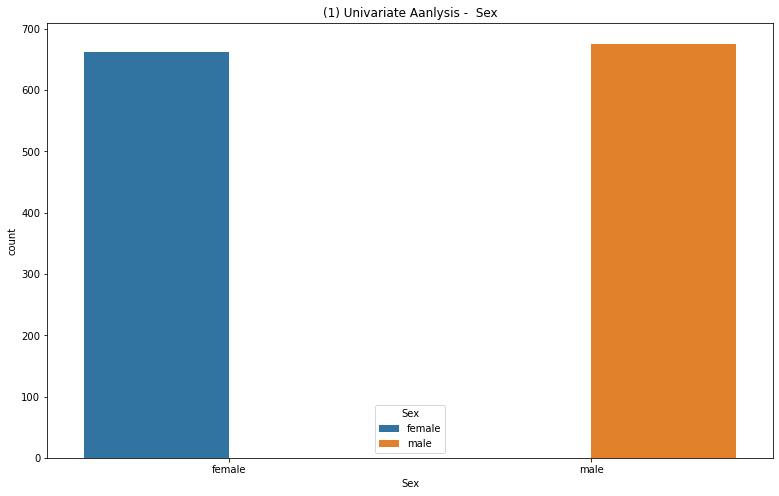

```python
mlp.figure(figsize=(13,8))
sb.countplot(data["Sex"],hue=data["Sex"])
mlp.title("(1) Univariate Aanlysis -  Sex")
```

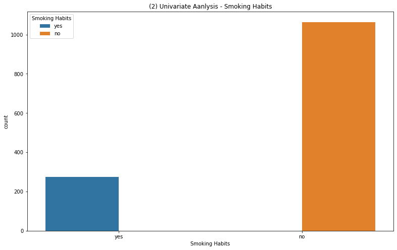

```python
mlp.figure(figsize=(13,8))
sb.countplot(data["Smoking Habits"],hue=data["Smoking Habits"])
mlp.title("(2) Univariate Aanlysis - Smoking Habits")
```

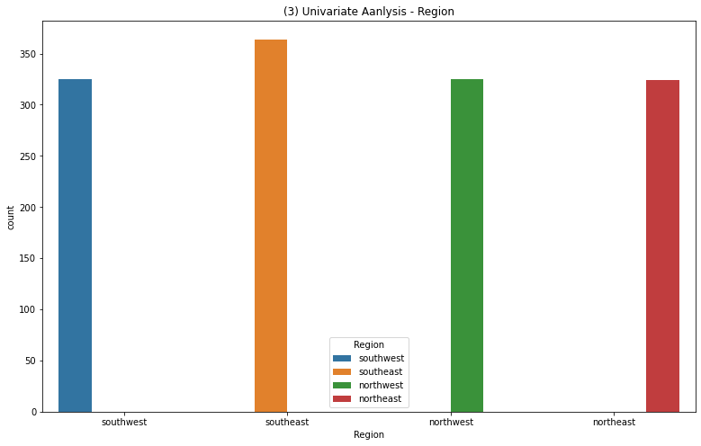

```python
mlp.figure(figsize=(13,8))
sb.countplot(data["Region"],hue=data["Region"])
mlp.title("(3) Univariate Aanlysis - Region")
```

**Univariate Analysis - Numerical or Continuous Parameters**

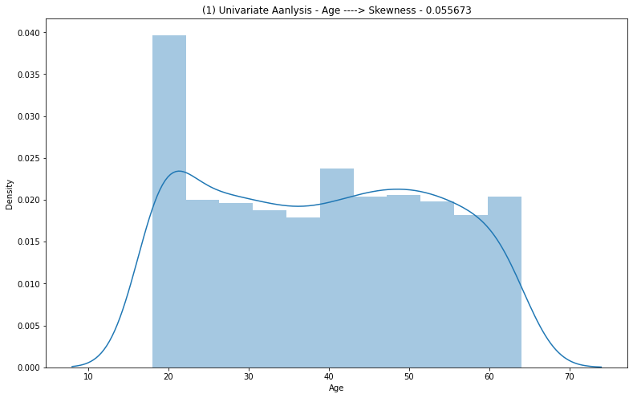

```python
mlp.figure(figsize=(13,8))
sb.distplot(data["Age"])
mlp.title("(1) Univariate Aanlysis - Age ----> Skewness - 0.055673")
```

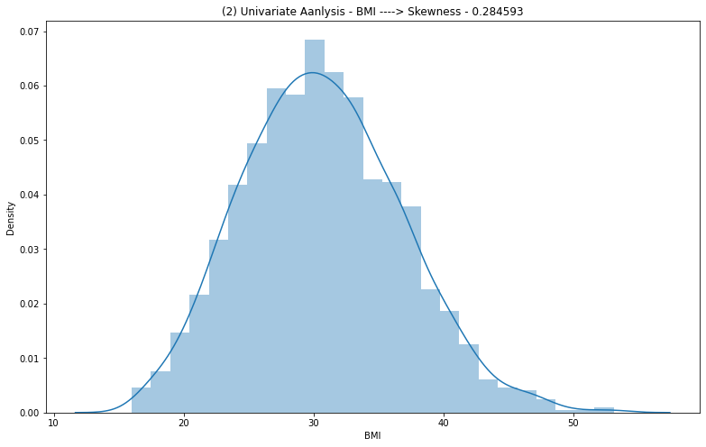

```python
mlp.figure(figsize=(13,8))
sb.distplot(data["BMI"])
mlp.title("(2) Univariate Aanlysis - BMI ----> Skewness - 0.284593")
```

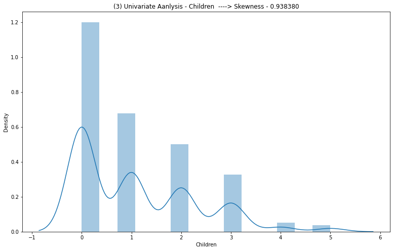

```python
mlp.figure(figsize=(13,8))
sb.distplot(data["Children"])
mlp.title("(3) Univariate Aanlysis - Children  ----> Skewness - 0.938380")
```

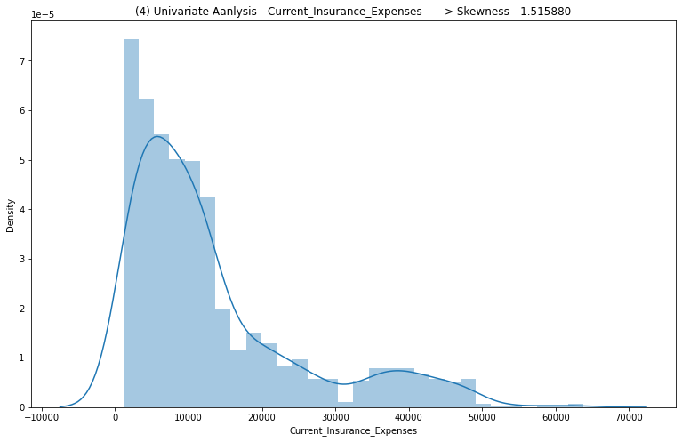

```python
mlp.figure(figsize=(13,8))
sb.distplot(data["Current_Insurance_Expenses"])
mlp.title("(4) Univariate Aanlysis - Current_Insurance_Expenses  ----> Skewness - 1.515880")
```

```python
data[con].skew()
```

```
Age                           0.055673
BMI                           0.284593
Children                      0.938380
Current_Insurance_Expenses    1.515880
dtype: float64
```

**Bivariate Analysis - Categorical Parameters**

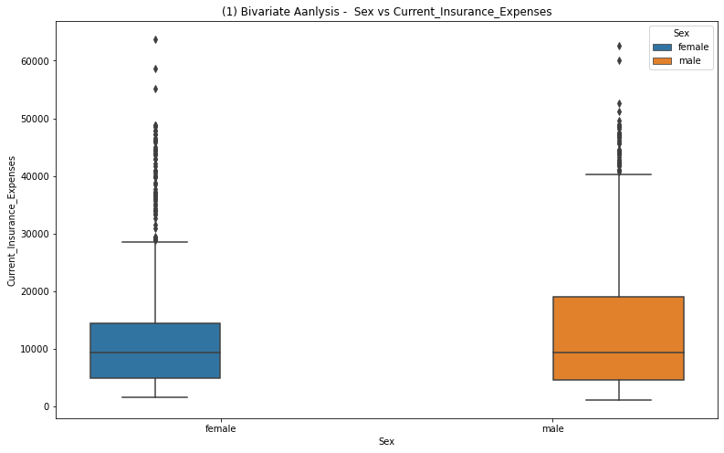

```python
mlp.figure(figsize=(13,8))
sb.boxplot(data["Sex"],data["Current_Insurance_Expenses"],hue=data["Sex"])
mlp.title("(1) Bivariate Aanlysis -  Sex vs Current_Insurance_Expenses")
```

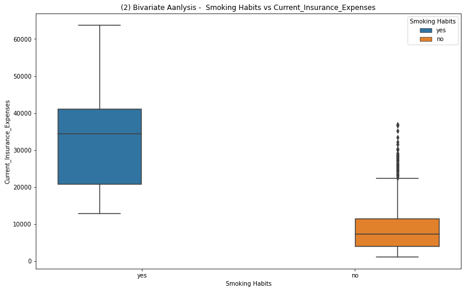

```python
mlp.figure(figsize=(13,8))
sb.boxplot(data["Smoking Habits"],data["Current_Insurance_Expenses"],hue=data["Smoking Habits"])
mlp.title("(2) Bivariate Aanlysis -  Smoking Habits vs Current_Insurance_Expenses")
```

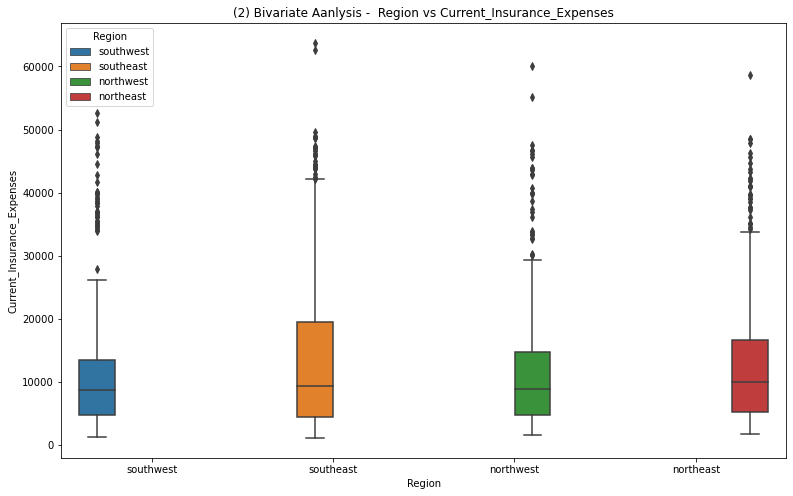

```python
mlp.figure(figsize=(13,8))
sb.boxplot(data["Region"],data["Current_Insurance_Expenses"],hue=data["Region"])
mlp.title("(2) Bivariate Aanlysis -  Region vs Current_Insurance_Expenses")
```

**Bivariate Analysis - Continuous or Numerical Parameters**

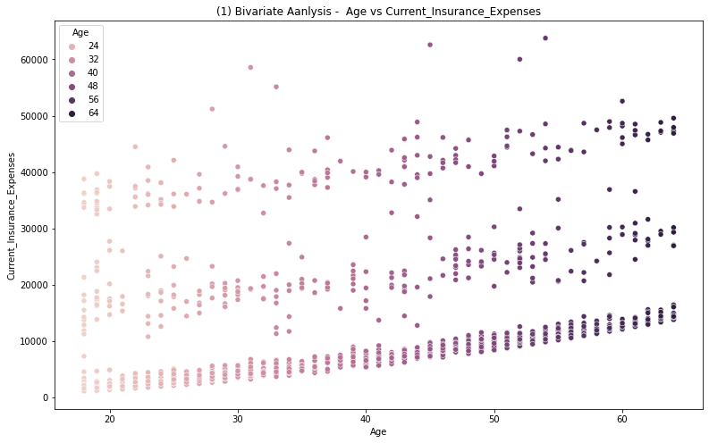

```python
mlp.figure(figsize=(13,8))
sb.scatterplot(data["Age"],data["Current_Insurance_Expenses"],hue=data["Age"])
mlp.title("(1) Bivariate Aanlysis -  Age vs Current_Insurance_Expenses")
```

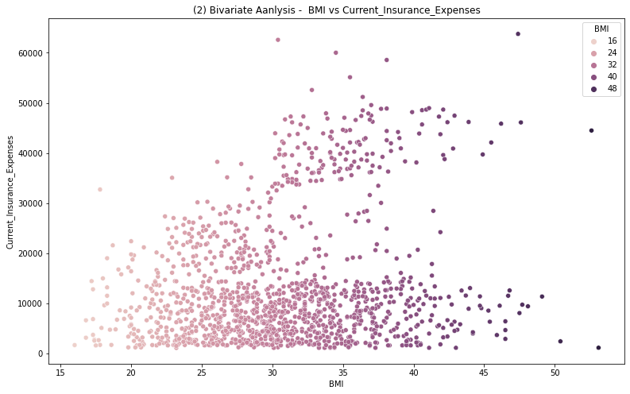

```python
mlp.figure(figsize=(13,8))
sb.scatterplot(data["BMI"],data["Current_Insurance_Expenses"],hue=data["BMI"])
mlp.title("(2) Bivariate Aanlysis -  BMI vs Current_Insurance_Expenses")
```

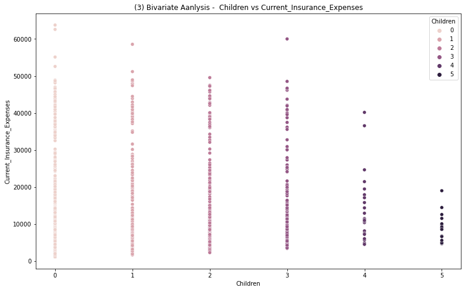

```python
mlp.figure(figsize=(13,8))
sb.scatterplot(data["Children"],data["Current_Insurance_Expenses"],hue=data["Children"])
mlp.title("(3) Bivariate Aanlysis -  Children vs Current_Insurance_Expenses")
```

# *7) Identifying Outliers and Eliminating them if any-*

```python
from sklearn.preprocessing import StandardScaler
ss = StandardScaler ()
std_data = pd.DataFrame(ss.fit_transform(data[con]),columns=con)
```

```python
std_data
```

|  | Age | BMI | Children | Current_Insurance_Expenses |
| --- | --- | --- | --- | --- |
| 0 | -1.438764 | -0.453646 | -0.908614 | 0.298583 |
| 1 | -1.509965 | 0.514186 | -0.078767 | -0.953689 |
| 2 | -0.797954 | 0.382954 | 1.580926 | -0.728675 |
| 3 | -0.441948 | -1.306650 | -0.908614 | 0.719843 |
| 4 | -0.513149 | -0.289606 | -0.908614 | -0.776802 |
| ... | ... | ... | ... | ... |
| 1333 | 0.768473 | 0.054876 | 1.580926 | -0.220551 |
| 1334 | -1.509965 | 0.202511 | -0.908614 | -0.914002 |
| 1335 | -1.509965 | 1.022707 | -0.908614 | -0.961597 |
| 1336 | -1.296362 | -0.798128 | -0.908614 | -0.930361 |
| 1337 | 1.551686 | -0.256799 | -0.908614 | 1.311053 |

1338 rows × 4 columns

```python
rows_tobe_dropped = []

for i in con:
    out = list(std_data[(std_data[i]>3)|(std_data[i]<-3)].index)
    rows_tobe_dropped.extend(out)
```

```python
from numpy import unique
Outliers = unique(rows_tobe_dropped)
```

```python
Outliers
```

```
array([  32,   34,   71,  116,  166,  413,  425,  438,  543,  568,  577,
        640,  819,  847,  877,  932,  937,  969,  984, 1047, 1085, 1116,
       1130, 1146, 1230, 1245, 1272, 1300, 1317])
```

```python
len(Outliers)
```

```
29
```

```python
data = data.drop(index=Outliers,axis=0)
```

```python
data.shape
```

```
(1309, 7)
```

```python
data.index = range(0,1309,1)
```

```python
data
```

|  | Age | Sex | BMI | Children | Smoking Habits | Region | Current_Insurance_Expenses |
| --- | --- | --- | --- | --- | --- | --- | --- |
| 0 | 19 | female | 27.9 | 0 | yes | southwest | 16884.92 |
| 1 | 18 | male | 33.8 | 1 | no | southeast | 1725.55 |
| 2 | 28 | male | 33.0 | 3 | no | southeast | 4449.46 |
| 3 | 33 | male | 22.7 | 0 | no | northwest | 21984.47 |
| 4 | 32 | male | 28.9 | 0 | no | northwest | 3866.86 |
| ... | ... | ... | ... | ... | ... | ... | ... |
| 1304 | 50 | male | 31.0 | 3 | no | northwest | 10600.55 |
| 1305 | 18 | female | 31.9 | 0 | no | northeast | 2205.98 |
| 1306 | 18 | female | 36.9 | 0 | no | southeast | 1629.83 |
| 1307 | 21 | female | 25.8 | 0 | no | southwest | 2007.95 |
| 1308 | 61 | female | 29.1 | 0 | yes | northwest | 29141.36 |

1309 rows × 7 columns

# *8)Exploratory Data Analysis-(Post-Outliers Elimination)*

**Univariate Analysis -Categorical Parameters**

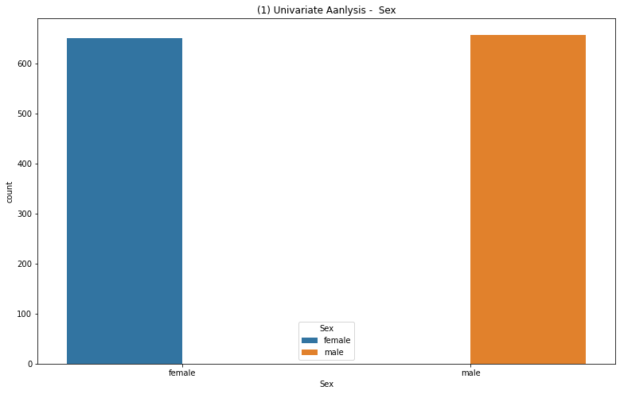

```python
mlp.figure(figsize=(13,8))
sb.countplot(data["Sex"],hue=data["Sex"])
mlp.title("(1) Univariate Aanlysis -  Sex")
```

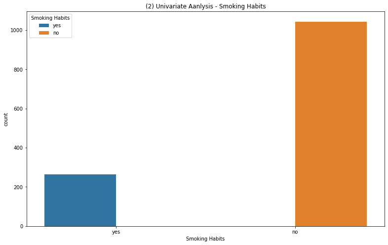

```python
mlp.figure(figsize=(13,8))
sb.countplot(data["Smoking Habits"],hue=data["Smoking Habits"])
mlp.title("(2) Univariate Aanlysis - Smoking Habits")
```

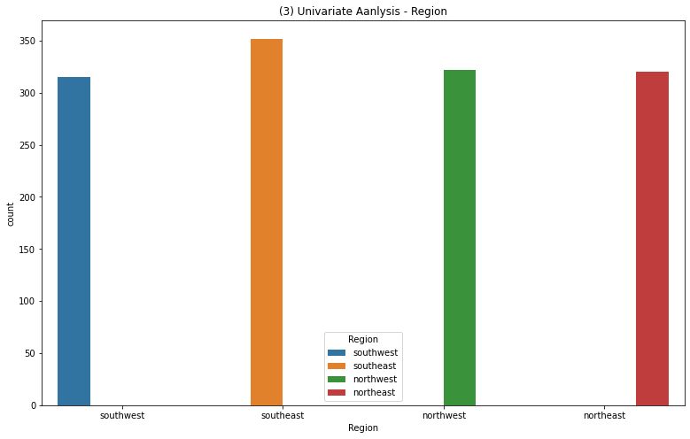

```python
mlp.figure(figsize=(13,8))
sb.countplot(data["Region"],hue=data["Region"])
mlp.title("(3) Univariate Aanlysis - Region")
```

**Univariate Analysis - Numerical or Continuous Parameters**

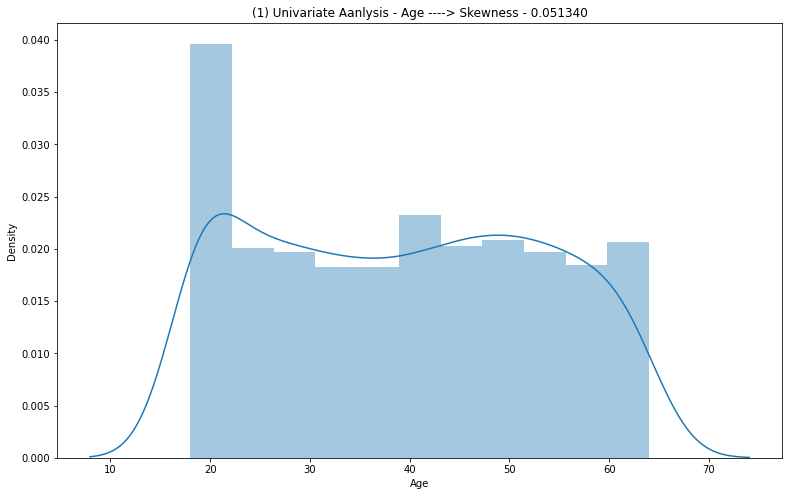

```python
mlp.figure(figsize=(13,8))
sb.distplot(data["Age"])
mlp.title("(1) Univariate Aanlysis - Age ----> Skewness - 0.051340")
```

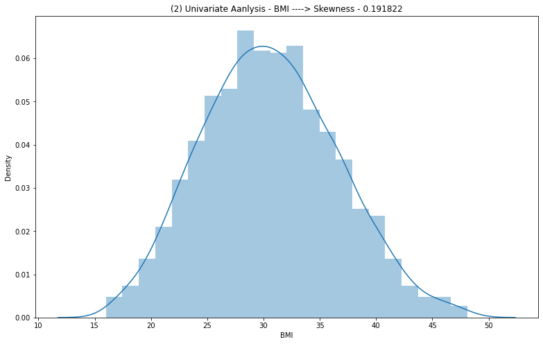

```python
mlp.figure(figsize=(13,8))
sb.distplot(data["BMI"])
mlp.title("(2) Univariate Aanlysis - BMI ----> Skewness - 0.191822")
```

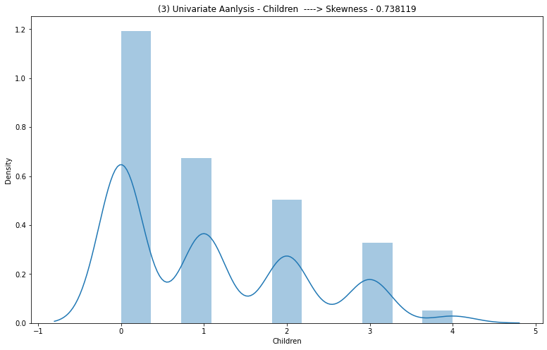

```python
mlp.figure(figsize=(13,8))
sb.distplot(data["Children"])
mlp.title("(3) Univariate Aanlysis - Children  ----> Skewness - 0.738119")
```

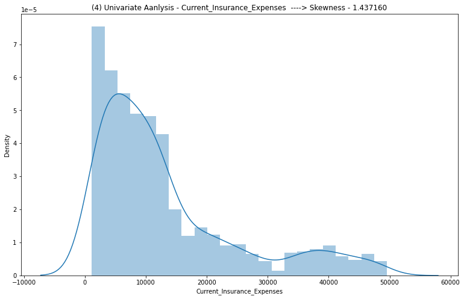

```python
mlp.figure(figsize=(13,8))
sb.distplot(data["Current_Insurance_Expenses"])
mlp.title("(4) Univariate Aanlysis - Current_Insurance_Expenses  ----> Skewness - 1.437160")
```

```python
data[con].skew()
```

```
Age                           0.051340
BMI                           0.191822
Children                      0.738119
Current_Insurance_Expenses    1.437160
dtype: float64
```

**Bivariate Analysis - Categorical Parameters**

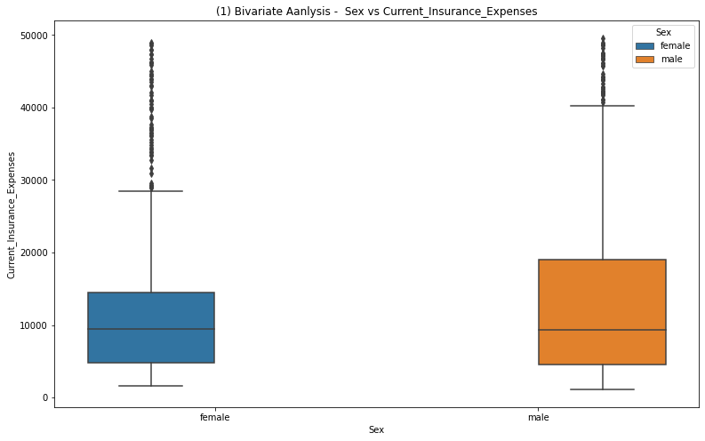

```python
mlp.figure(figsize=(13,8))
sb.boxplot(data["Sex"],data["Current_Insurance_Expenses"],hue=data["Sex"])
mlp.title("(1) Bivariate Aanlysis -  Sex vs Current_Insurance_Expenses")
```

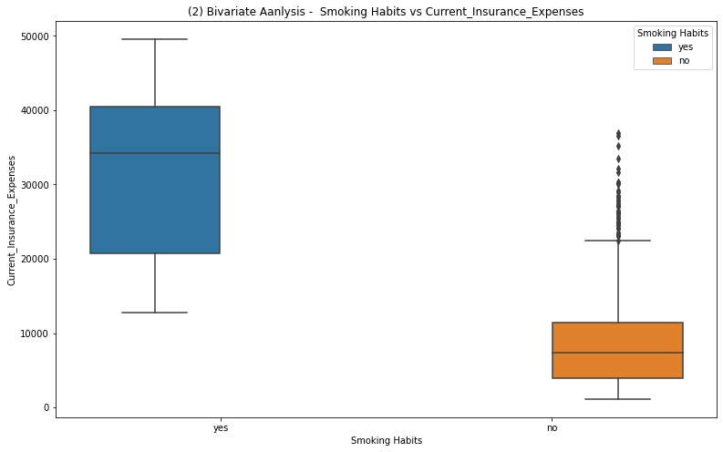

```python
mlp.figure(figsize=(13,8))
sb.boxplot(data["Smoking Habits"],data["Current_Insurance_Expenses"],hue=data["Smoking Habits"])
mlp.title("(2) Bivariate Aanlysis -  Smoking Habits vs Current_Insurance_Expenses")
```

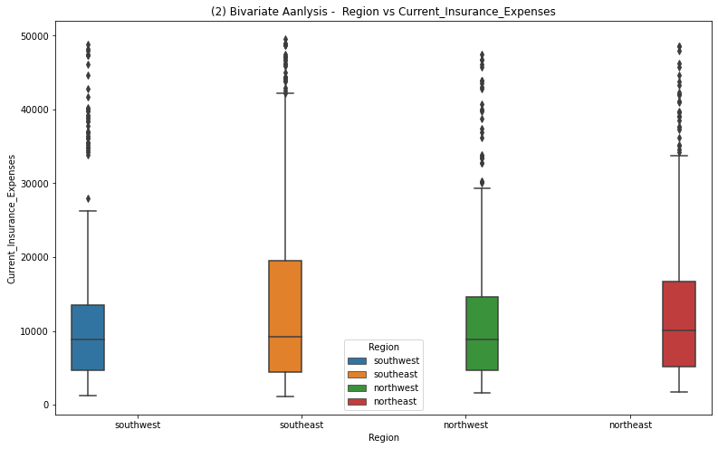

```python
mlp.figure(figsize=(13,8))
sb.boxplot(data["Region"],data["Current_Insurance_Expenses"],hue=data["Region"])
mlp.title("(2) Bivariate Aanlysis -  Region vs Current_Insurance_Expenses")
```

**Bivariate Analysis - Continuous or Numerical Parameters**

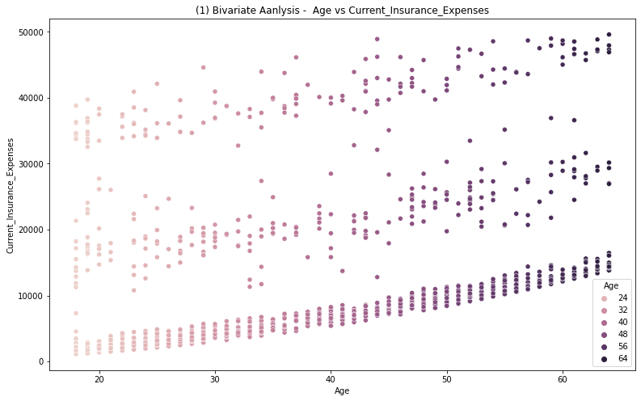

```python
mlp.figure(figsize=(13,8))
sb.scatterplot(data["Age"],data["Current_Insurance_Expenses"],hue=data["Age"])
mlp.title("(1) Bivariate Aanlysis -  Age vs Current_Insurance_Expenses")
```

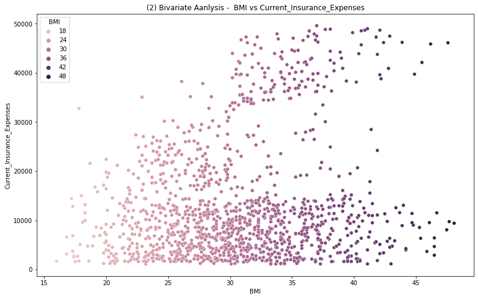

```python
mlp.figure(figsize=(13,8))
sb.scatterplot(data["BMI"],data["Current_Insurance_Expenses"],hue=data["BMI"])
mlp.title("(2) Bivariate Aanlysis -  BMI vs Current_Insurance_Expenses")
```

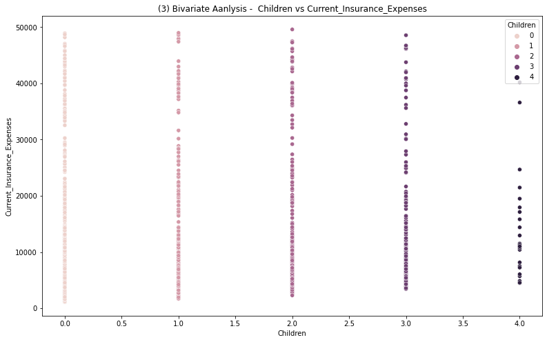

```python
mlp.figure(figsize=(13,8))
sb.scatterplot(data["Children"],data["Current_Insurance_Expenses"],hue=data["Children"])
mlp.title("(3) Bivariate Aanlysis -  Children vs Current_Insurance_Expenses")
```

# *9)Understanding the Correlation-*

```python
data.corr()[["Current_Insurance_Expenses"]].sort_values(by="Current_Insurance_Expenses",ascending=False)
```

|  | Current_Insurance_Expenses |
| --- | --- |
| Current_Insurance_Expenses | 1.000000 |
| Age | 0.305263 |
| BMI | 0.191691 |
| Children | 0.100438 |

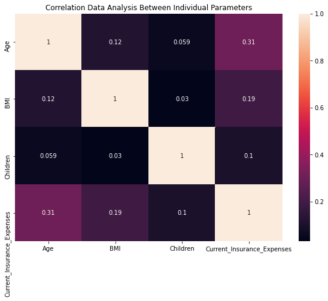

```python
mlp.figure(figsize=(10,7))
sb.heatmap(data.corr(),annot=True)
mlp.title("Correlation Data Analysis Between Individual Parameters")
```

# *10) Preprocessing of entire Dataset for futher model predictions-*

```python
Y = data[["Current_Insurance_Expenses"]]
X = data.drop(columns="Current_Insurance_Expenses",axis=1)
```

```python
Y
```

|  | Current_Insurance_Expenses |
| --- | --- |
| 0 | 16884.92 |
| 1 | 1725.55 |
| 2 | 4449.46 |
| 3 | 21984.47 |
| 4 | 3866.86 |
| ... | ... |
| 1304 | 10600.55 |
| 1305 | 2205.98 |
| 1306 | 1629.83 |
| 1307 | 2007.95 |
| 1308 | 29141.36 |

1309 rows × 1 columns

```python
X
```

|  | Age | Sex | BMI | Children | Smoking Habits | Region |
| --- | --- | --- | --- | --- | --- | --- |
| 0 | 19 | female | 27.9 | 0 | yes | southwest |
| 1 | 18 | male | 33.8 | 1 | no | southeast |
| 2 | 28 | male | 33.0 | 3 | no | southeast |
| 3 | 33 | male | 22.7 | 0 | no | northwest |
| 4 | 32 | male | 28.9 | 0 | no | northwest |
| ... | ... | ... | ... | ... | ... | ... |
| 1304 | 50 | male | 31.0 | 3 | no | northwest |
| 1305 | 18 | female | 31.9 | 0 | no | northeast |
| 1306 | 18 | female | 36.9 | 0 | no | southeast |
| 1307 | 21 | female | 25.8 | 0 | no | southwest |
| 1308 | 61 | female | 29.1 | 0 | yes | northwest |

1309 rows × 6 columns

```python
xcat = []
xcon = []

for i in X.columns:
    if(X[i].dtypes == "object"):
        xcat.append(i)
    else:
        xcon.append(i)
```

```python
xcat
```

```
['Sex', 'Smoking Habits', 'Region']
```

```python
xcon
```

```
['Age', 'BMI', 'Children']
```

# *11) Feature Engineering-*

*Standardization of continuous columns-*

```python
from sklearn.preprocessing import StandardScaler
ss = StandardScaler ()
data_X1std = pd.DataFrame(ss.fit_transform(X[xcon]),columns=xcon)
```

```python
data_X1std
```

|  | Age | BMI | Children |
| --- | --- | --- | --- |
| 0 | -1.439063 | -0.449713 | -0.929616 |
| 1 | -1.510086 | 0.538052 | -0.040093 |
| 2 | -0.799859 | 0.404118 | 1.738954 |
| 3 | -0.444746 | -1.320285 | -0.929616 |
| 4 | -0.515769 | -0.282295 | -0.929616 |
| ... | ... | ... | ... |
| 1304 | 0.762639 | 0.069282 | 1.738954 |
| 1305 | -1.510086 | 0.219958 | -0.929616 |
| 1306 | -1.510086 | 1.057047 | -0.929616 |
| 1307 | -1.297018 | -0.801290 | -0.929616 |
| 1308 | 1.543888 | -0.248812 | -0.929616 |

1309 rows × 3 columns

*One hot encoding of Categorical columns-*

```python
data_X2std = pd.get_dummies(X[xcat])
```

```python
data_X2std
```

|  | Sex_female | Sex_male | Smoking Habits_no | Smoking Habits_yes | Region_northeast | Region_northwest | Region_southeast | Region_southwest |
| --- | --- | --- | --- | --- | --- | --- | --- | --- |
| 0 | 1 | 0 | 0 | 1 | 0 | 0 | 0 | 1 |
| 1 | 0 | 1 | 1 | 0 | 0 | 0 | 1 | 0 |
| 2 | 0 | 1 | 1 | 0 | 0 | 0 | 1 | 0 |
| 3 | 0 | 1 | 1 | 0 | 0 | 1 | 0 | 0 |
| 4 | 0 | 1 | 1 | 0 | 0 | 1 | 0 | 0 |
| ... | ... | ... | ... | ... | ... | ... | ... | ... |
| 1304 | 0 | 1 | 1 | 0 | 0 | 1 | 0 | 0 |
| 1305 | 1 | 0 | 1 | 0 | 1 | 0 | 0 | 0 |
| 1306 | 1 | 0 | 1 | 0 | 0 | 0 | 1 | 0 |
| 1307 | 1 | 0 | 1 | 0 | 0 | 0 | 0 | 1 |
| 1308 | 1 | 0 | 0 | 1 | 0 | 1 | 0 | 0 |

1309 rows × 8 columns

```python
data_XAstd = data_X1std.join(data_X2std)
```

```python
data_XAstd
```

|  | Age | BMI | Children | Sex_female | Sex_male | Smoking Habits_no | Smoking Habits_yes | Region_northeast | Region_northwest | Region_southeast | Region_southwest |
| --- | --- | --- | --- | --- | --- | --- | --- | --- | --- | --- | --- |
| 0 | -1.439063 | -0.449713 | -0.929616 | 1 | 0 | 0 | 1 | 0 | 0 | 0 | 1 |
| 1 | -1.510086 | 0.538052 | -0.040093 | 0 | 1 | 1 | 0 | 0 | 0 | 1 | 0 |
| 2 | -0.799859 | 0.404118 | 1.738954 | 0 | 1 | 1 | 0 | 0 | 0 | 1 | 0 |
| 3 | -0.444746 | -1.320285 | -0.929616 | 0 | 1 | 1 | 0 | 0 | 1 | 0 | 0 |
| 4 | -0.515769 | -0.282295 | -0.929616 | 0 | 1 | 1 | 0 | 0 | 1 | 0 | 0 |
| ... | ... | ... | ... | ... | ... | ... | ... | ... | ... | ... | ... |
| 1304 | 0.762639 | 0.069282 | 1.738954 | 0 | 1 | 1 | 0 | 0 | 1 | 0 | 0 |
| 1305 | -1.510086 | 0.219958 | -0.929616 | 1 | 0 | 1 | 0 | 1 | 0 | 0 | 0 |
| 1306 | -1.510086 | 1.057047 | -0.929616 | 1 | 0 | 1 | 0 | 0 | 0 | 1 | 0 |
| 1307 | -1.297018 | -0.801290 | -0.929616 | 1 | 0 | 1 | 0 | 0 | 0 | 0 | 1 |
| 1308 | 1.543888 | -0.248812 | -0.929616 | 1 | 0 | 0 | 1 | 0 | 1 | 0 | 0 |

1309 rows × 11 columns

# *12)Divide data in training & testing set-*

```python
from sklearn.model_selection import train_test_split
xtrain,xtest,ytrain,ytest = train_test_split(data_XAstd,Y,test_size=0.2,random_state=21)
```

```python
print(xtrain.shape)
print(ytest.shape)
print(ytrain.shape)
print(ytest.shape)
```

```
(1047, 11)
(262, 1)
(1047, 1)
(262, 1)
```